# EDA Template

Brittany Blackmon and Eric Graham

2025-05-28

# Setup and Data Import

```r
df = read.csv("HospitalDurations.csv", header = TRUE)
names(df)
```

```
##  [1] "ID"           "Lgth.of.Sty"  "Age"          "Inf.Risk"     "R.Cul.Rat"
##  [6] "R.CX.ray.Rat" "N.Beds"       "Med.Sc.Aff"   "Region"       "Avg.Pat"
## [11] "Avg.Nur"      "Pct.Ser.Fac"
```

# Exploratory Data Analysis

## Variable Classification and Basic Cleaning

Our response variable is Length of Stay. For Analysis 1, we’re performing an inferential analysis on the relationship between infection risk and length of stay, but we will also explore the relationships between length of stay and other predictors.

For Analysis 2, we will build two predictive models: one complex MLR and one random forest model.

We don’t need to perform any analysis on the ID variable, so we dropped it from the dataframe.

Because Medical School Affiliation and Region are categorical variables, we will convert them to factors and clearly relabel them.

The remainder of our predictors are numeric, and we’ll further identify which are continuous and which are discrete later in the analysis.

```r
response_var = "Lgth.of.Sty"

df = df %>% select(-ID)

df$Med.Sc.Aff <- factor(df$Med.Sc.Aff, levels = c(1, 2), labels = c("Yes", "No"))
df$Region <- factor(df$Region, levels = c(1, 2, 3, 4), labels = c("NE", "NC", "S", "W"))

cat_vars = df %>% select(where(is.factor)) %>% names()
num_vars = df %>% select(where(is.numeric)) %>% names()

num_vars = setdiff(num_vars, response_var)

# cat_vars
# num_vars
```

```r
head(df)
```

```
##   Lgth.of.Sty  Age Inf.Risk R.Cul.Rat R.CX.ray.Rat N.Beds Med.Sc.Aff Region
## 1        7.13 55.7      4.1       9.0         39.6    279         No      W
## 2        8.82 58.2      1.6       3.8         51.7     80         No     NC
## 3        8.34 56.9      2.7       8.1         74.0    107         No      S
## 4        8.95 53.7      5.6      18.9        122.8    147         No      W
## 5       11.20 56.5      5.7      34.5         88.9    180         No     NE
## 6        9.76 50.9      5.1      21.9         97.0    150         No     NC
##   Avg.Pat Avg.Nur Pct.Ser.Fac
## 1     207     241          60
## 2      51      52          40
## 3      82      54          20
## 4      53     148          40
## 5     134     151          40
## 6     147     106          40
```

```r
glimpse(df)
```

```
## Rows: 113
## Columns: 11
## $ Lgth.of.Sty  <dbl> 7.13, 8.82, 8.34, 8.95, 11.20, 9.76, 9.68, 11.18, 8.67, 8…
## $ Age          <dbl> 55.7, 58.2, 56.9, 53.7, 56.5, 50.9, 57.8, 45.7, 48.2, 56.…
## $ Inf.Risk     <dbl> 4.1, 1.6, 2.7, 5.6, 5.7, 5.1, 4.6, 5.4, 4.3, 6.3, 4.9, 4.…
## $ R.Cul.Rat    <dbl> 9.0, 3.8, 8.1, 18.9, 34.5, 21.9, 16.7, 60.5, 24.4, 29.6, …
## $ R.CX.ray.Rat <dbl> 39.6, 51.7, 74.0, 122.8, 88.9, 97.0, 79.0, 85.8, 90.8, 82…
## $ N.Beds       <int> 279, 80, 107, 147, 180, 150, 186, 640, 182, 85, 768, 167,…
## $ Med.Sc.Aff   <fct> No, No, No, No, No, No, No, Yes, No, No, Yes, No, Yes, No…
## $ Region       <fct> W, NC, S, W, NE, NC, S, NC, S, NE, NE, S, NE, NC, S, S, W…
## $ Avg.Pat      <int> 207, 51, 82, 53, 134, 147, 151, 399, 130, 59, 591, 105, 2…
## $ Avg.Nur      <int> 241, 52, 54, 148, 151, 106, 129, 360, 118, 66, 656, 59, 3…
## $ Pct.Ser.Fac  <dbl> 60.0, 40.0, 20.0, 40.0, 40.0, 40.0, 40.0, 60.0, 40.0, 40.…
```

```r
skim(df)
```

Data summary

| Name | df |
| --- | --- |
| Number of rows | 113 |
| Number of columns | 11 |
| _______________________ |  |
| Column type frequency: |  |
| factor | 2 |
| numeric | 9 |
| ________________________ |  |
| Group variables | None |

**Variable type: factor**

| skim_variable | n_missing | complete_rate | ordered | n_unique | top_counts |
| --- | --- | --- | --- | --- | --- |
| Med.Sc.Aff | 0 | 1 | FALSE | 2 | No: 96, Yes: 17 |
| Region | 0 | 1 | FALSE | 4 | S: 37, NC: 32, NE: 28, W: 16 |

**Variable type: numeric**

| skim_variable | n_missing | complete_rate | mean | sd | p0 | p25 | p50 | p75 | p100 | hist |
| --- | --- | --- | --- | --- | --- | --- | --- | --- | --- | --- |
| Lgth.of.Sty | 0 | 1 | 9.65 | 1.91 | 6.7 | 8.34 | 9.42 | 10.47 | 19.56 | ▇▇▁▁▁ |
| Age | 0 | 1 | 53.23 | 4.46 | 38.8 | 50.90 | 53.20 | 56.20 | 65.90 | ▁▂▇▃▁ |
| Inf.Risk | 0 | 1 | 4.35 | 1.34 | 1.3 | 3.70 | 4.40 | 5.20 | 7.80 | ▂▃▇▃▁ |
| R.Cul.Rat | 0 | 1 | 15.79 | 10.23 | 1.6 | 8.40 | 14.10 | 20.30 | 60.50 | ▇▆▂▁▁ |
| R.CX.ray.Rat | 0 | 1 | 81.63 | 19.36 | 39.6 | 69.50 | 82.30 | 94.10 | 133.50 | ▃▅▇▃▁ |
| N.Beds | 0 | 1 | 252.17 | 192.84 | 29.0 | 106.00 | 186.00 | 312.00 | 835.00 | ▇▅▂▁▁ |
| Avg.Pat | 0 | 1 | 191.37 | 153.76 | 20.0 | 68.00 | 143.00 | 252.00 | 791.00 | ▇▃▂▁▁ |
| Avg.Nur | 0 | 1 | 173.25 | 139.27 | 14.0 | 66.00 | 132.00 | 218.00 | 656.00 | ▇▅▂▁▁ |
| Pct.Ser.Fac | 0 | 1 | 43.16 | 15.20 | 5.7 | 31.40 | 42.90 | 54.30 | 80.00 | ▁▆▇▆▂ |

Using the glimpse() and skim() functions, we can see that data has been gathered from 113 hospitals. This is a relatively small number, which will need to be addressed in modeling.

The data types are appropriate for our analysis. The categorical variables are factors, and the numeric variables are either integers or doubles.

Our skim() of the data above showed that there are no missing values, so removal of incomplete records or imputation of missing variables won’t be necessary.

## Variable Glossary Table

```r
data.frame(
  Variable_Name = c(
    "Hospital ID", "Length of Stay", "Age", "Infection risk",
    "Routine culturing ratio", "Routine chest X-ray ratio",
    "Number of beds", "Medical School Affiliation", "Region",
    "Average Daily census", "Number of nurses", "Available facilities"
  ),
  Description = c(
    "Unique identifier for the hospital",
    "Average length of stay (in days)",
    "Average age of patients (years)",
    "Estimated probability of hospital infection (%)",
    "(# of cultures / # of asymptomatic patients) × 100",
    "(# of chest X-rays / # of asymptomatic patients) × 100",
    "Average number of beds",
    "Whether the hospital is affiliated with a medical school (Yes or No)",
    "Geographic region (NE, NC, S, or W)",
    "Average number of patients in hospital per day",
    "Average number of full-time nurses",
    "Percent of 35 possible facilities and services provided"
  ),
  `Data Type` = c("character", "double", "double", "double", "double", "double", "integer", "factor", "factor", "integer", "integer", "double"),
  Type = c("categorical", "continuous", "continuous", "continuous", "continuous", "continuous", "discrete", "categorical", "categorical", "continuous", "continuous", "continuous")
) |>
  kable()
```

| Variable_Name | Description | Data.Type | Type |
| --- | --- | --- | --- |
| Hospital ID | Unique identifier for the hospital | character | categorical |
| Length of Stay | Average length of stay (in days) | double | continuous |
| Age | Average age of patients (years) | double | continuous |
| Infection risk | Estimated probability of hospital infection (%) | double | continuous |
| Routine culturing ratio | (# of cultures / # of asymptomatic patients) × 100 | double | continuous |
| Routine chest X-ray ratio | (# of chest X-rays / # of asymptomatic patients) × 100 | double | continuous |
| Number of beds | Average number of beds | integer | discrete |
| Medical School Affiliation | Whether the hospital is affiliated with a medical school (Yes or No) | factor | categorical |
| Region | Geographic region (NE, NC, S, or W) | factor | categorical |
| Average Daily census | Average number of patients in hospital per day | integer | continuous |
| Number of nurses | Average number of full-time nurses | integer | continuous |
| Available facilities | Percent of 35 possible facilities and services provided | double | continuous |

## Univariate Analysis

### Discrete vs. Continuous Classification

Though the number of beds in a hospital is a discrete variable, the distribution of values in this dataset is so wide that bar plots wouldn’t be interpretable. We have chosen to treat it as continuous for the purposes of our analysis.

```r
# dictionary of feature names and labels
label_dict <- c(
  "ID"             = "Hospital ID",
  "Lgth.of.Sty"    = "Length of Stay (days)",
  "Age"            = "Average Age (years)",
  "Inf.Risk"       = "Infection Risk",
  "R.Cul.Rat"      = "Routine Culturing Ratio (%)",
  "R.CX.ray.Rat"   = "Routine Chest X-ray Ratio (%)",
  "N.Beds"         = "Number of Beds",
  "Med.Sc.Aff"     = "Medical School Affiliation",
  "Region"         = "Region",
  "Avg.Pat"        = "Average Daily Census",
  "Avg.Nur"        = "Number of Nurses",
  "Pct.Ser.Fac"    = "Available Facilities (%)"
)
# helper function to strip underscores and convert to title case
pretty_var = function(x) {
  gsub("_", " ", tools::toTitleCase(x))
}
# helper function to get labels from dictionary
get_label <- function(varname) {
  if (varname %in% names(label_dict)) {
    return(label_dict[[varname]])
  } else {
    return(pretty_var(varname))
  }
}
```

### Distribution of Response Variable

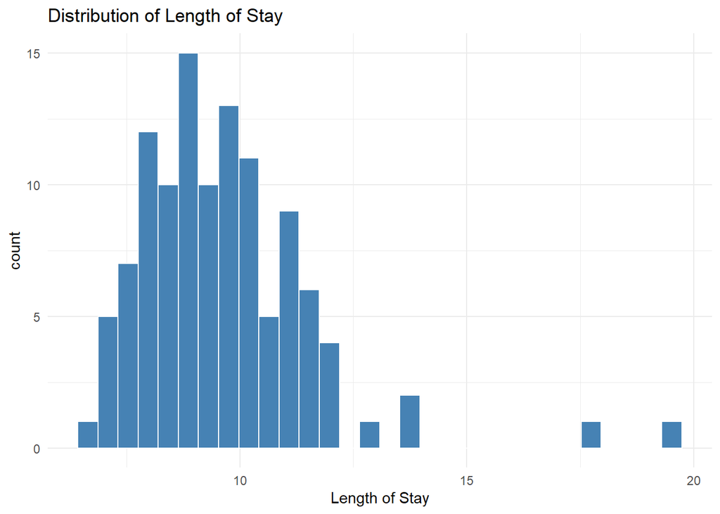

```r
p = ggplot(df, aes(x = Lgth.of.Sty)) +
  geom_histogram(fill = "steelblue", color = "white") +
  labs(
    x = "Length of Stay",
    title = "Distribution of Length of Stay"
  ) +
  theme_minimal()

print(p)
```

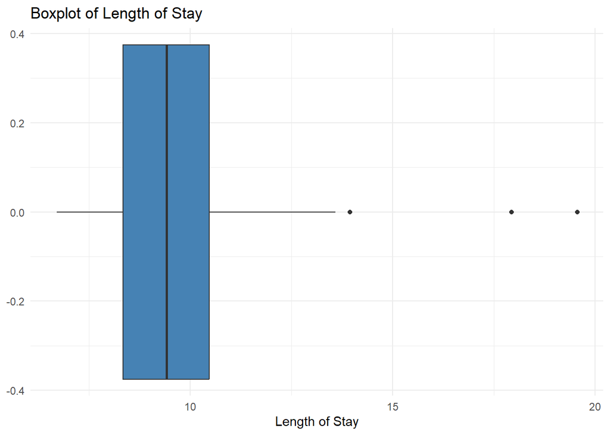

```r
p = ggplot(df, aes(y = Lgth.of.Sty)) +
  geom_boxplot(fill = "steelblue") +
  coord_flip() +
  labs(y = "Length of Stay", title = "Boxplot of Length of Stay") +
  theme_minimal()

print(p)
```

The distribution of lengths of stay is mostly normal, with two notable outliers. If there are issues with fit diagnostics then we might consider a transformation, but given the shape of our response variable it seems more likely that we would look to transformations on predictors.

### Numeric Predictors

**Click to expand: Numeric Variable Plots**

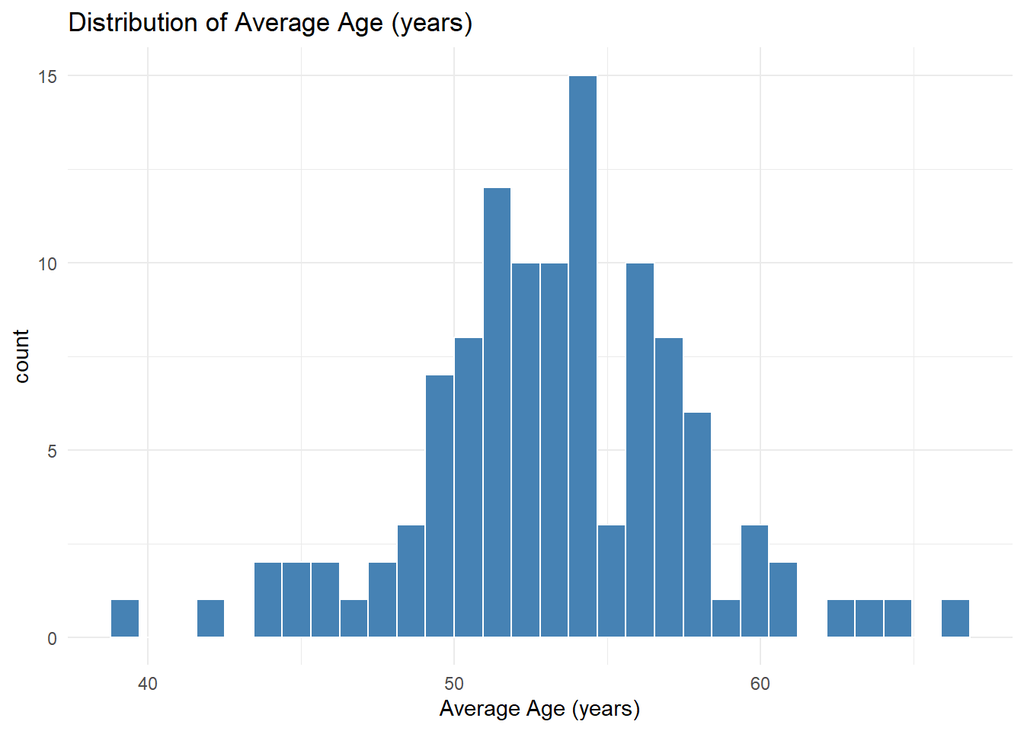

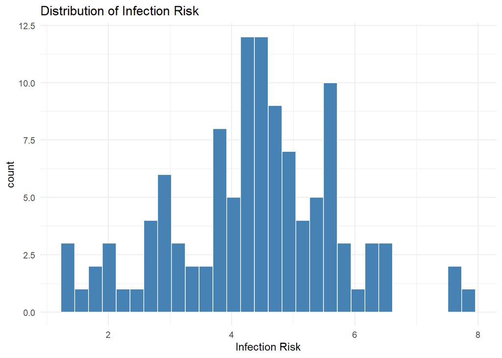

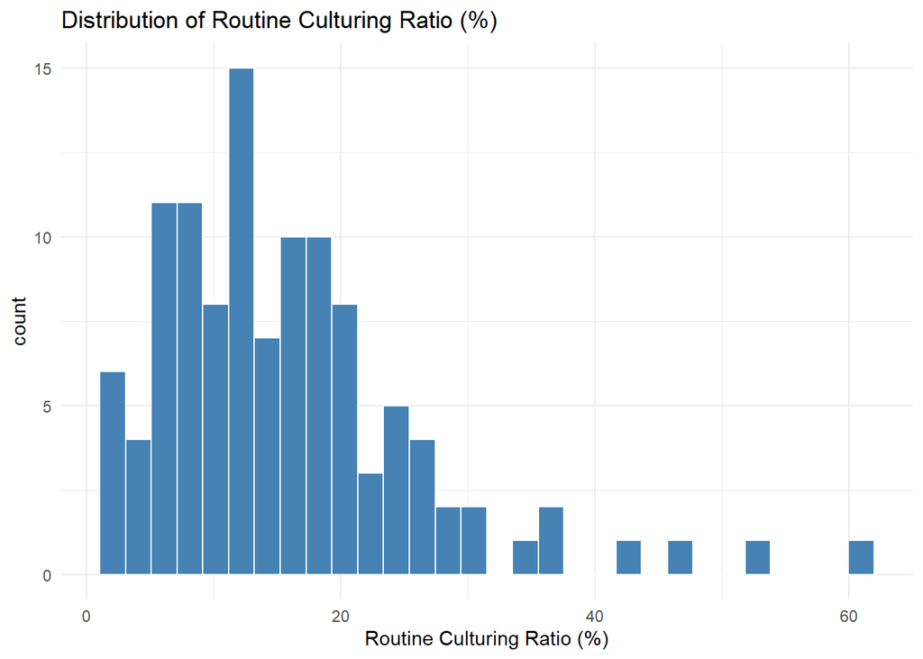

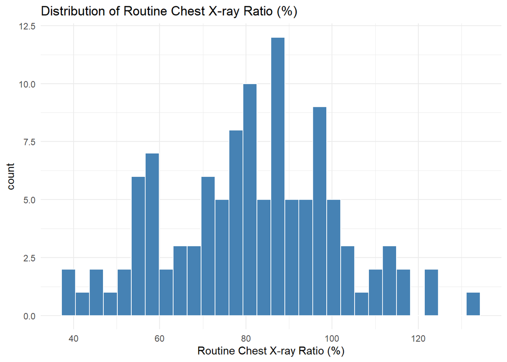

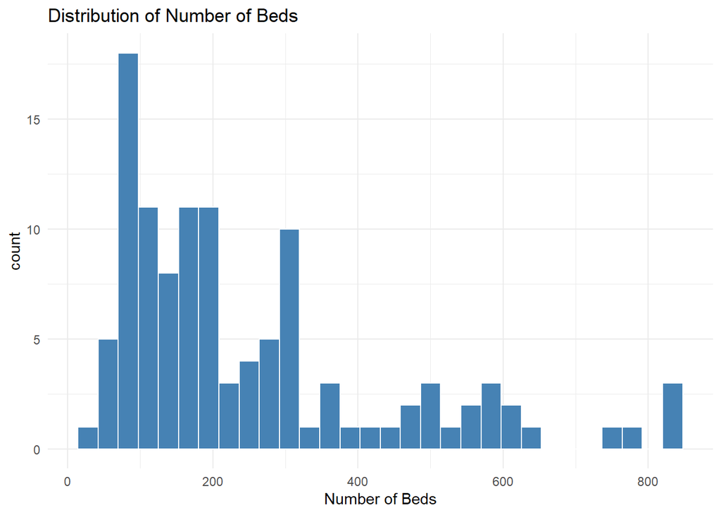

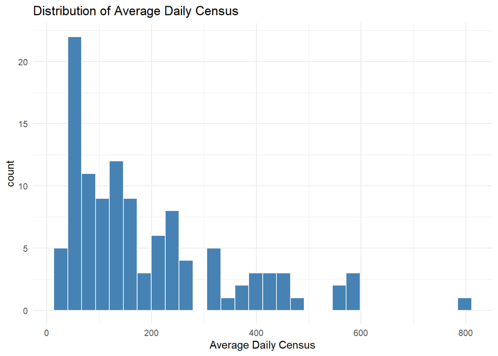

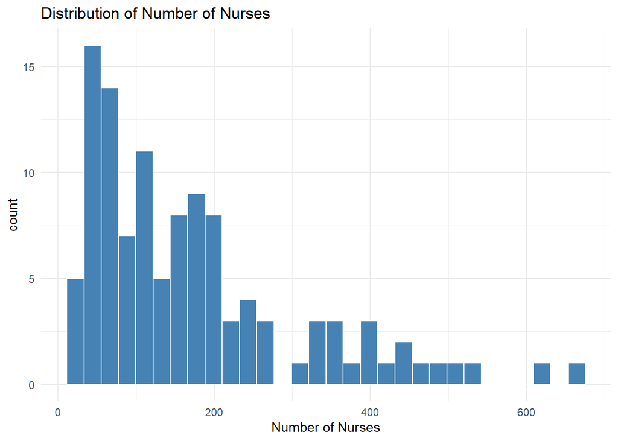

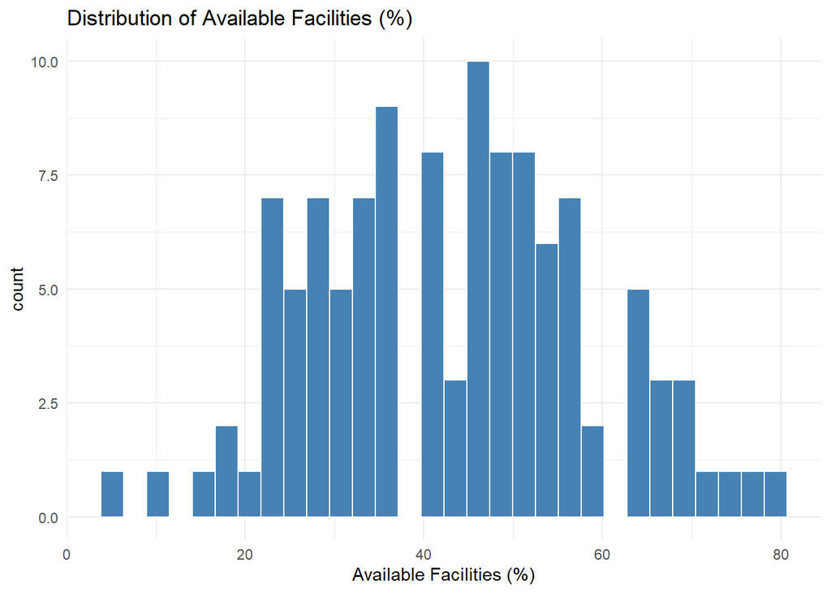

```r
for (var in num_vars) {
  p <- ggplot(df, aes(x = !!sym(var))) +
    geom_histogram(fill = "steelblue", color = "white") +
    labs(
      x = get_label(var),
      title = paste("Distribution of", get_label(var))
    ) +
    theme_minimal()

  print(p)
}
```

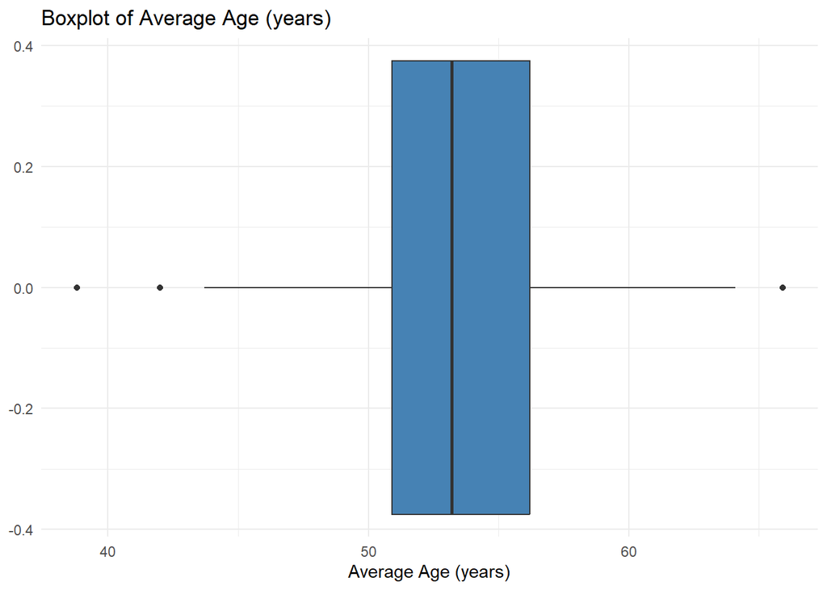

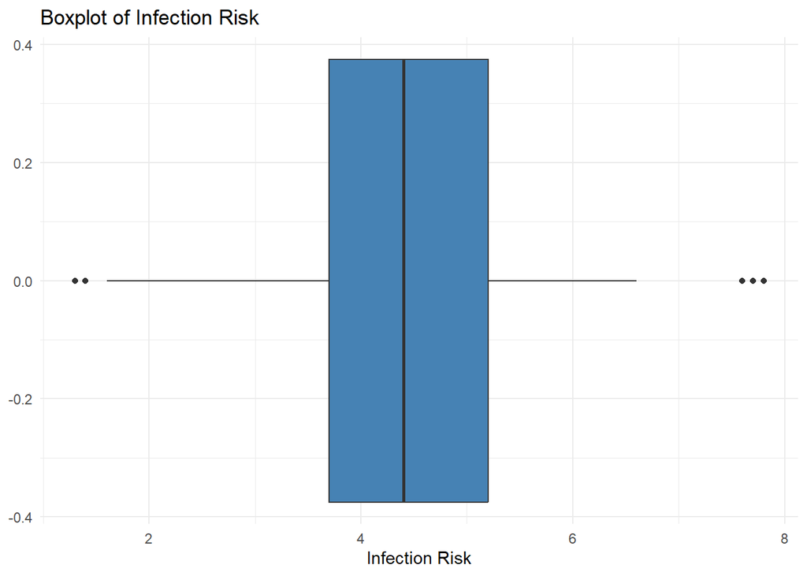

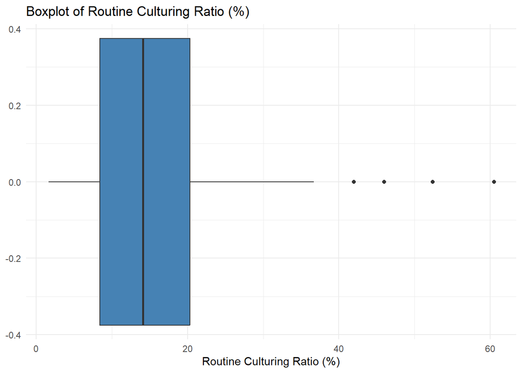

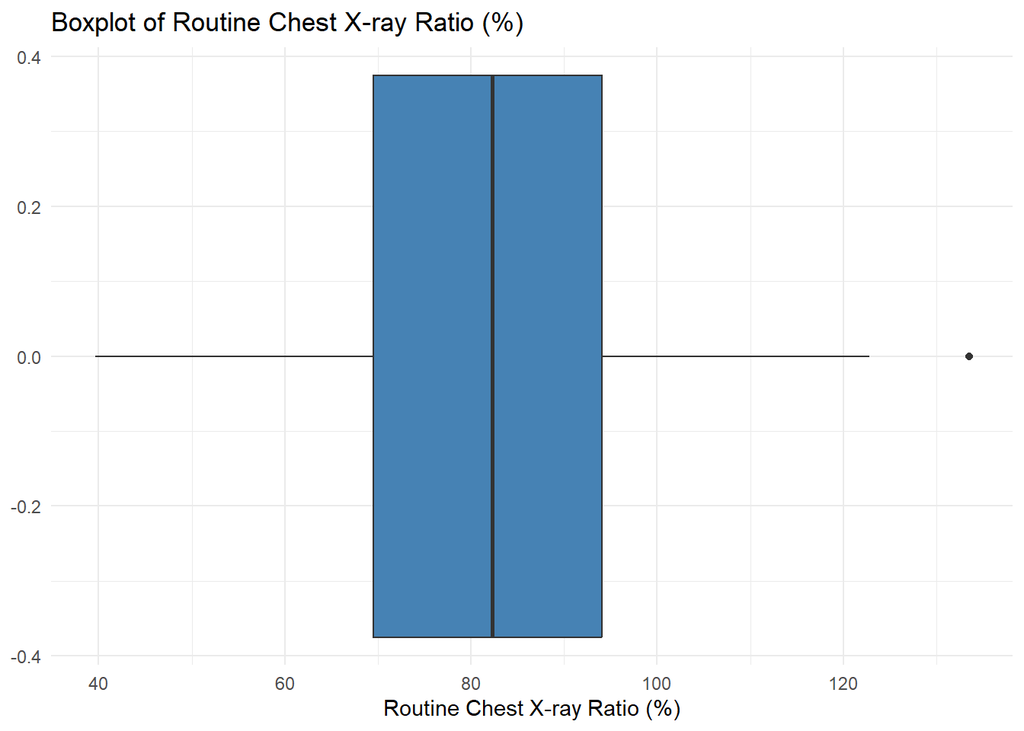

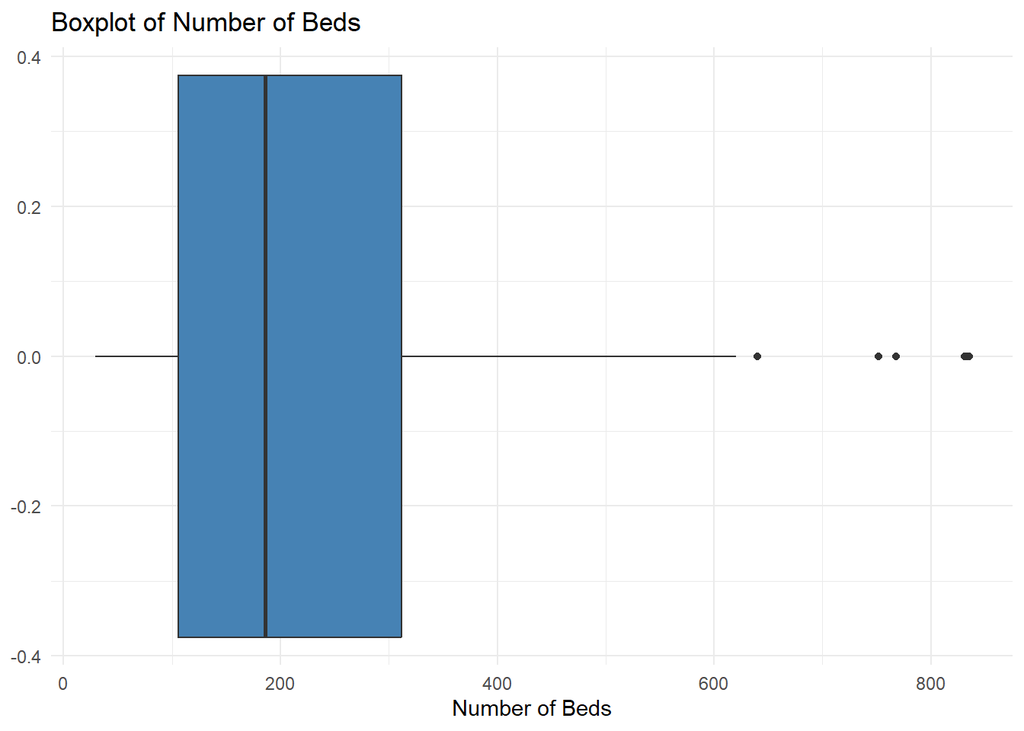

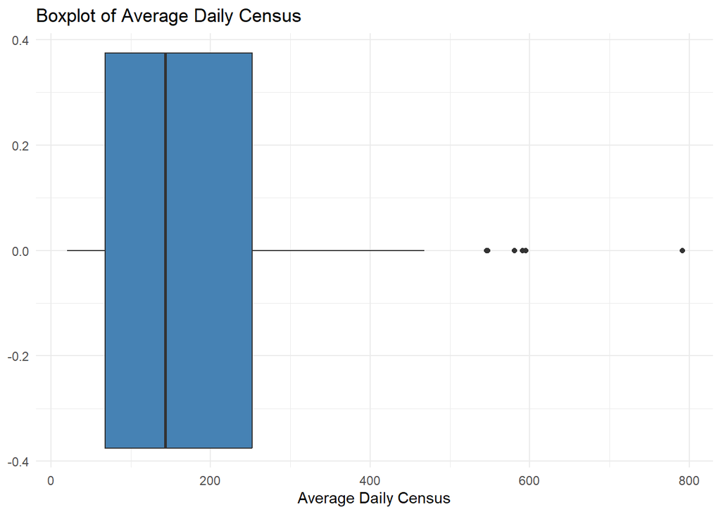

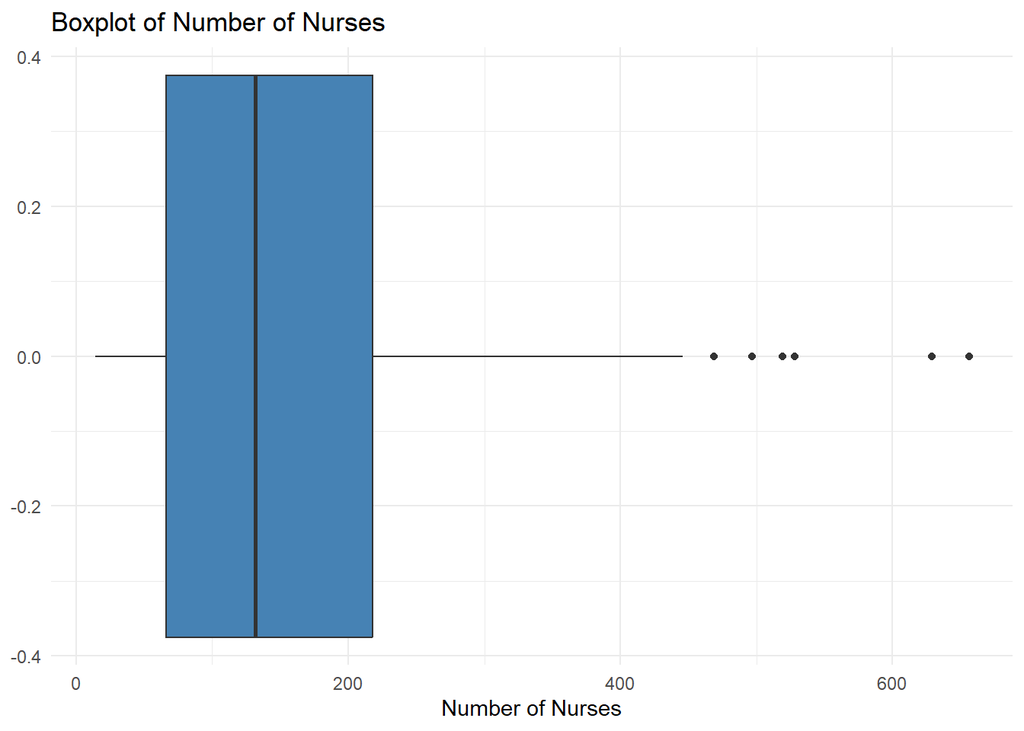

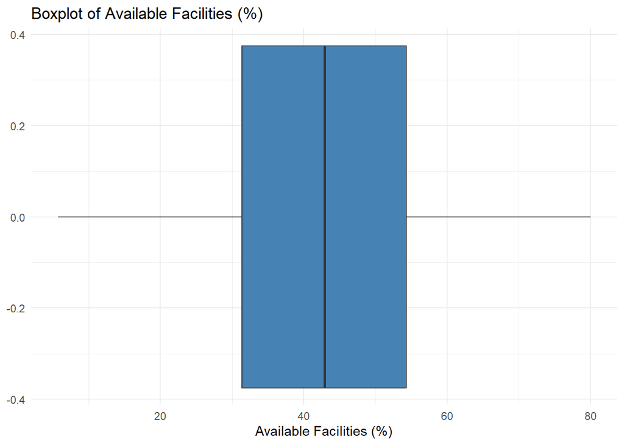

```r
for (var in num_vars) {
  p = ggplot(df, aes(y = !!sym(var))) +
    geom_boxplot(fill = "steelblue") +
    coord_flip() +
    labs(y = get_label(var), title = paste("Boxplot of", get_label(var))) +
    theme_minimal()
  print(p)
}
```

### Categorical Variables

**Click to expand: Categorical Variable Plots**

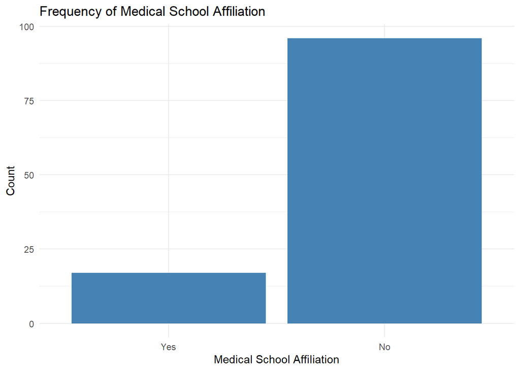

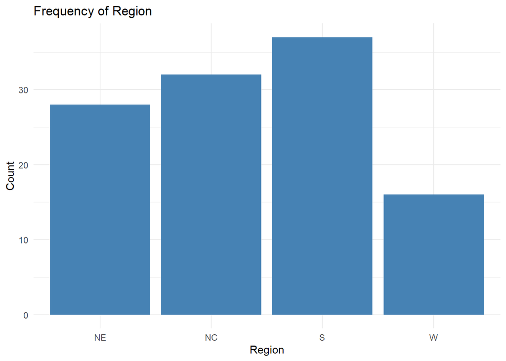

```r
for (var in cat_vars) {
  p = ggplot(df, aes(x = !!sym(var))) +
    geom_bar(fill = "steelblue") +
    labs(
      x = get_label(var),
      y = "Count",
      title = paste("Frequency of", get_label(var))
    ) +
    theme_minimal()

  print(p)
}
```

We note that medical school affiliation is imbalanced: the majority of schools don’t have a medical school affiliation. This may impact its usefulness in a train/test split for the predictive model, so we will need to keep an eye on that.

### Outlier Analysis

```r
outlier_summary = data.frame()

for (var in num_vars) {
  values = df[[var]]
  q1 = quantile(values, 0.25, na.rm = TRUE)
  q3 = quantile(values, 0.75, na.rm = TRUE)
  iqr = q3 - q1
  lower = q1 - 1.5 * iqr
  upper = q3 + 1.5 * iqr
  outliers = sum(values < lower | values > upper, na.rm = TRUE)
  pct = 100 * outliers / sum(!is.na(values))
  outlier_summary = rbind(
    outlier_summary,
    data.frame(variable = var, num_outliers = outliers, pct_outliers = round(pct, 1))
  )
}

outlier_summary
```

```
##       variable num_outliers pct_outliers
## 1          Age            3          2.7
## 2     Inf.Risk            6          5.3
## 3    R.Cul.Rat            4          3.5
## 4 R.CX.ray.Rat            1          0.9
## 5       N.Beds            6          5.3
## 6      Avg.Pat            6          5.3
## 7      Avg.Nur            6          5.3
## 8  Pct.Ser.Fac            0          0.0
```

We see some outliers in our predictors, but none of them are extreme enough to warrant removal. We will be keeping an eye out for high-leverage points in our model fit diagnostics.

## Bivariate / Multivariate Analysis

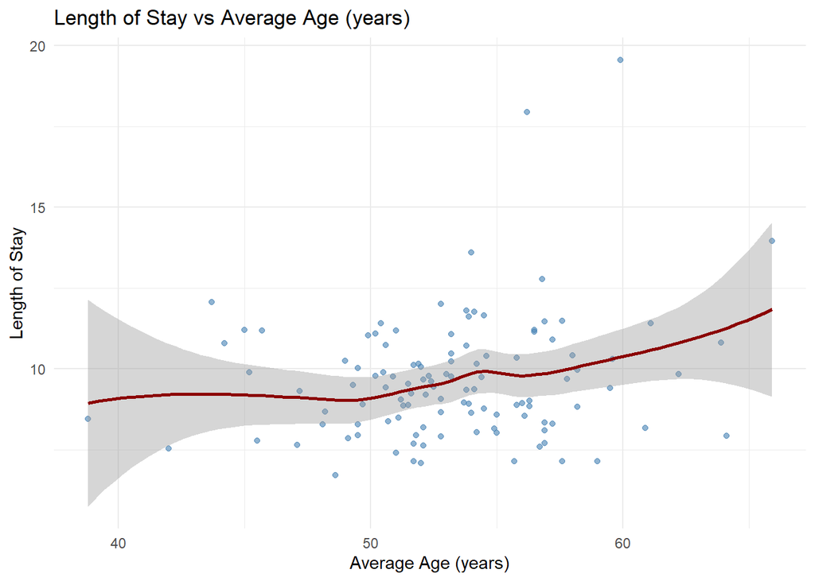

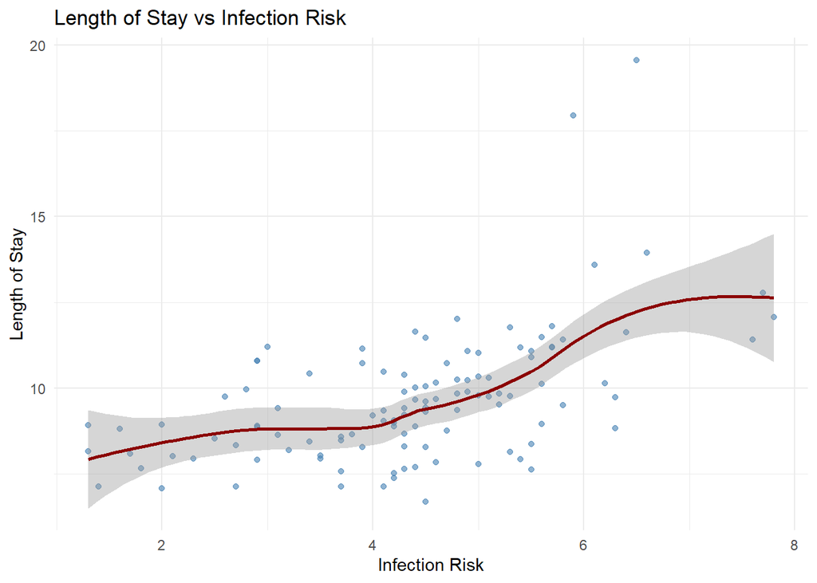

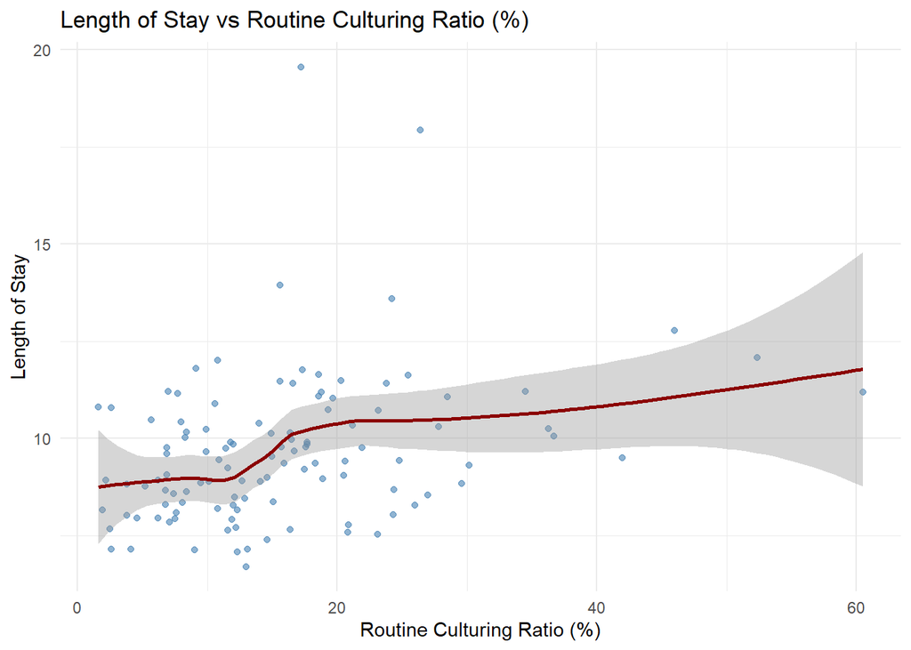

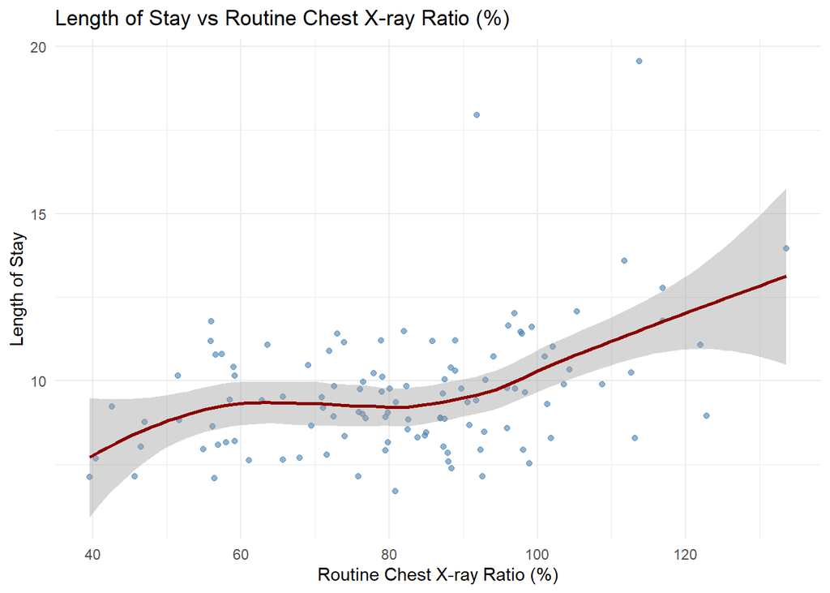

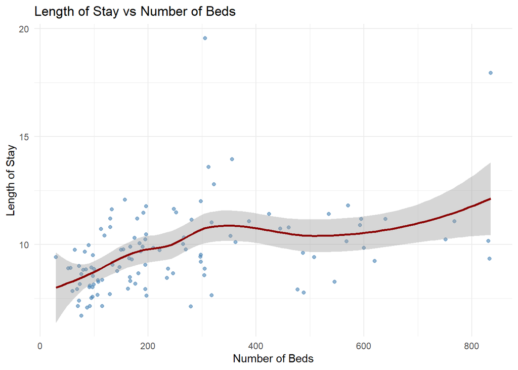

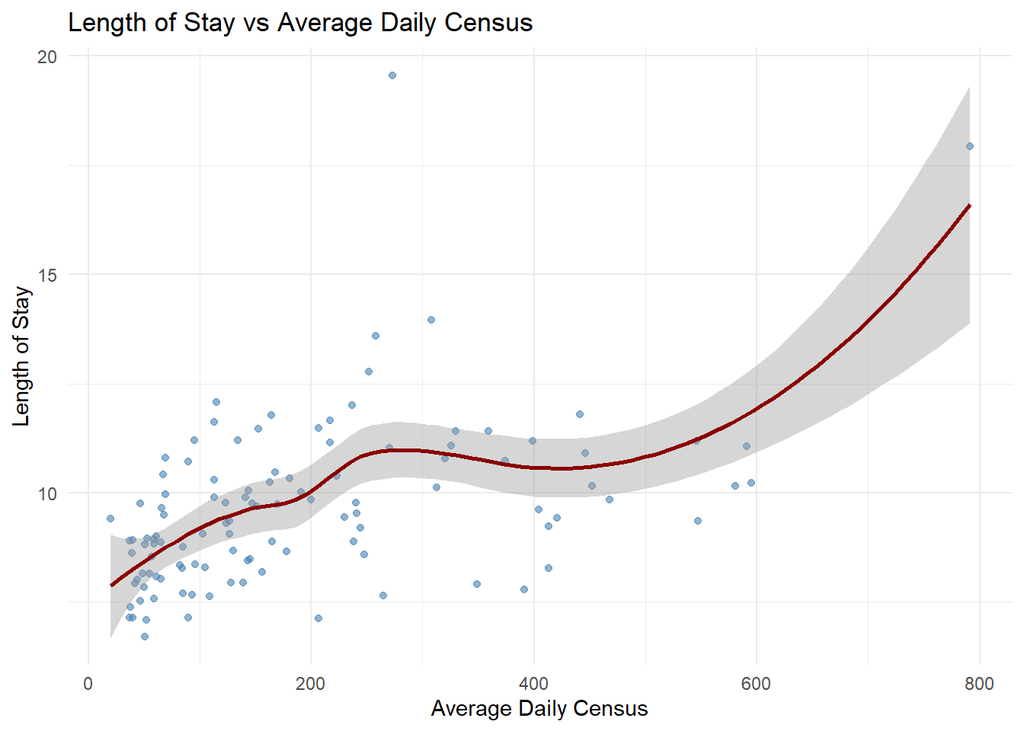

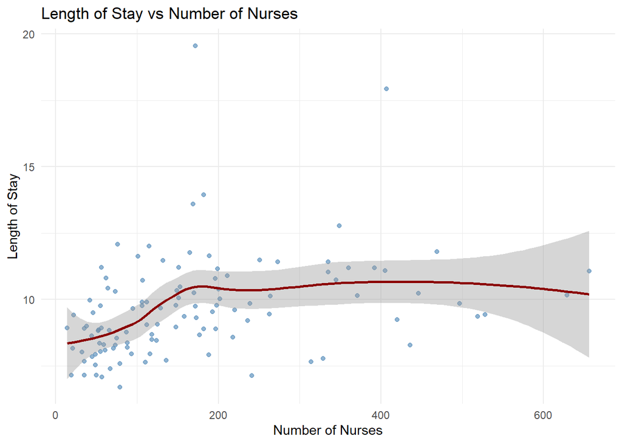

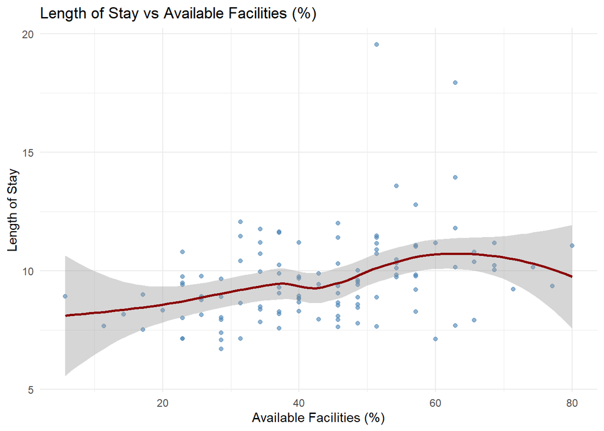

```r
for (var in num_vars) {
  p = ggplot(df, aes(x = !!sym(var), y = Lgth.of.Sty)) +
    geom_point(alpha = 0.6, color = "steelblue") +
    geom_smooth(method = "loess", se = TRUE, color = "darkred", linetype = "solid") +
    labs(
      x = get_label(var),
      y = "Length of Stay",
      title = paste("Length of Stay vs", get_label(var))
    ) +
    theme_minimal()

  print(p)
}
```

A visual examination of the relationships between our numeric predictors and length of stay shows that there is a moderate, positive linear relationship between infection risk and length of stay, which is the most important relationship we will be exploring in our inferential model.

Average age has a weak positive linear relationship.

Routine culturing ratio has a slight rise in the 15%-20% range, then flattens.

The overall trend for these predictors is positive, but it’s difficult to call the relationships linear, and the shapes of the distributions are such that a simple log or polynomial transformation may not be sufficient to perfectly capture the relationships.

Though some relationships are more linear than others, we will proceed with the assumption that they are all linear for the purposes of our inferential model.

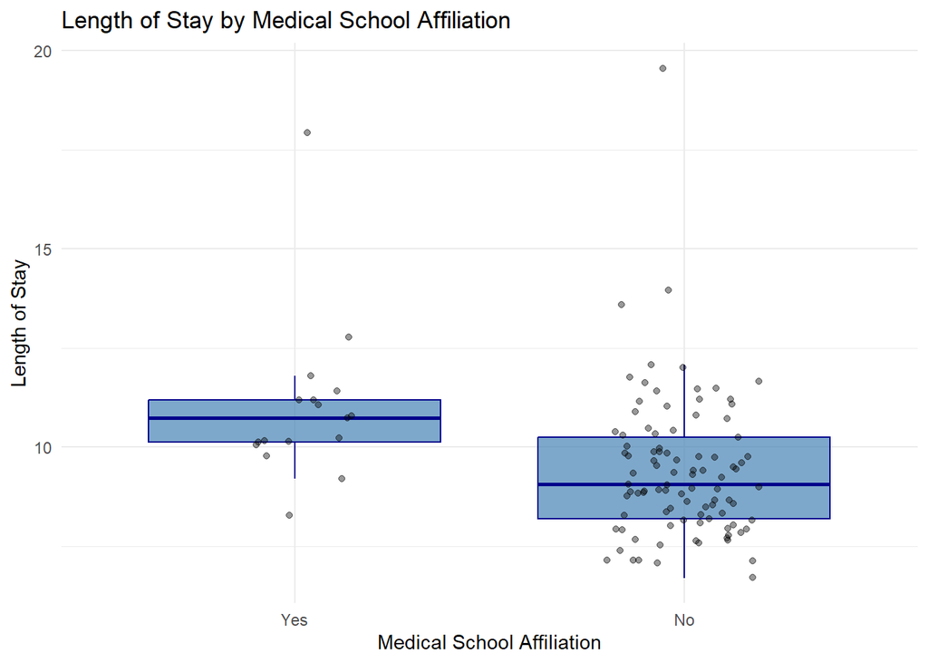

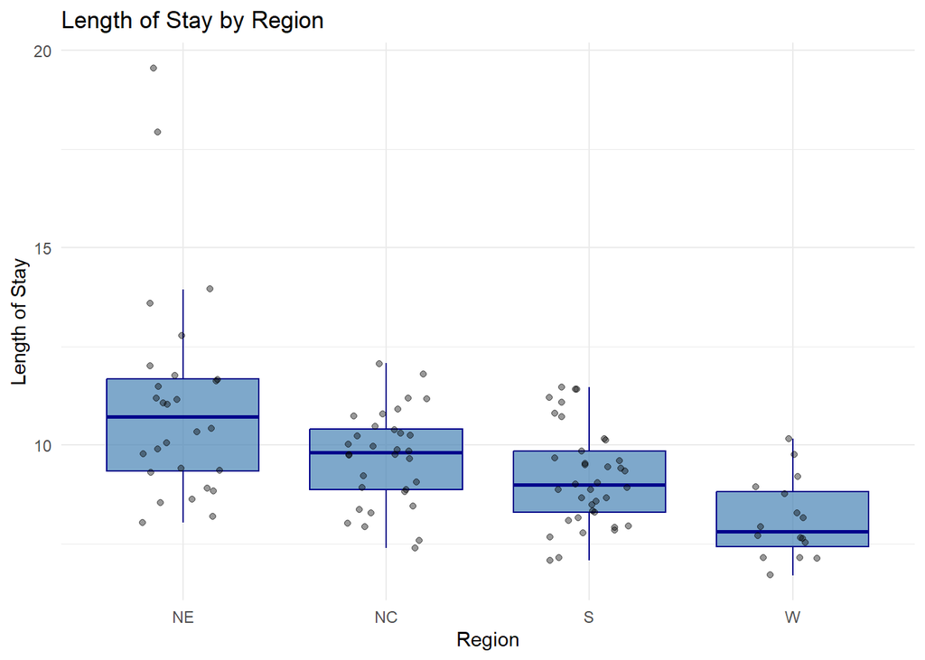

```r
for (var in cat_vars) {
  p = ggplot(df, aes(x = !!sym(var), y = Lgth.of.Sty)) +
    geom_boxplot(fill = "steelblue", color = "darkblue", outlier.shape = NA, alpha = 0.7) +
    geom_jitter(width = 0.2, alpha = 0.4, color = "black") +
    labs(
      x = get_label(var),
      y = "Length of Stay",
      title = paste("Length of Stay by", get_label(var))
    ) +
    theme_minimal()

  print(p)
}
```

A visual examination of the relationships between our categorical predictors and length of stay shows that the mean length of stay is generally higher among hospitals with a medical school affiliation, while region definitely appears to have an effect on length of stay, with the Northeast and North Central regions having the highest mean lengths of stay.